# Hands-on: Genomic Selection

Felipe Ferrão

2024-01-23

# 1 Introduction

Genomic selection refers to selection decisions based on genomic breeding values (GEBV). The GEBV can be computed using two equivalent models following these assumptions:

1. A model fitting individual SNP effects simultaneously. In this model, GEBV are computed as the sum of the effects of dense genetic markers, across the entire genome, thereby capturing all the quantitative trait loci that contribute to variation in a trait. This method can be referred as Ridge Regression, or SNP-BLUP or RR-BLUP. Relies on the genetic information based on **Marker-QTL LD**
2. A model estimating GEBV directly, by using mixed model equations and the covariance among breeding values defined by a genomic relationship matrices (G). Relies on the genetic information based on **Marker-Estimated Relationship**

Some important concepts:

- Training population (trn): genotypes and environments used to make predictions.
- Validation population (tst): group being predicted, or selection candidates
- Prediction accuracy: correlation between predicted and true values. Can be performed in cross-validation.

# 2 Simple vs. Multiple Regression

In the last class, we presented about the differences between simple and multiple regression and the advantages (and challenges) on using all predictors at the same time in the model.

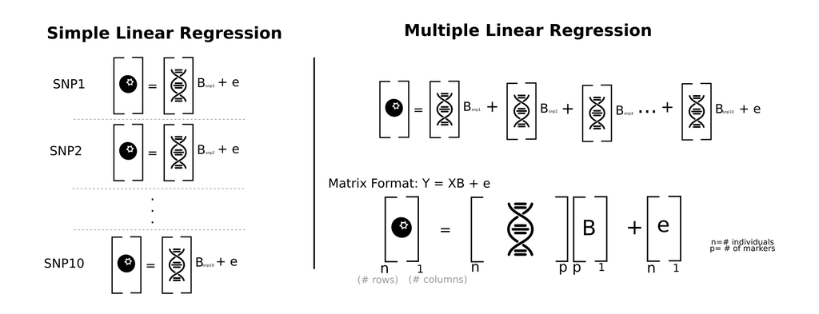

Below, the equation to estimate the $\beta$ effects:

$$\hat{\beta} =
(X'X)^{-1}X'y$$

## 2.1 Hand on

- Simulated 10 phenotypes
- Simulated 10 SNPs
- We will check the plots to see any visual association between phenotypic variation and SNP information
- Run one regression per time
- Try to run a multiple regression model and check the residual

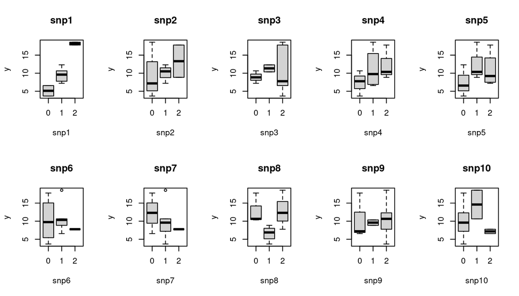

```r
# Simulating 5 values of berry size (mm)
set.seed(123)
y= rnorm (10,10,5)

# Simulating 5 snps in a diploid fashion
snp1 = c(1,1,2,1,1,2,1,0,0,1)
snp2 = c(1,2,2,1,1,0,1,0,0,0)
snp3 = c(0,0,2,1,0,2,1,2,2,2)
snp4 = c(1,2,2,2,0,1,1,0,1,0)
snp5 = c(2,1,2,1,2,1,0,0,0,2)
snp6 = c(0,1,0,1,1,1,0,0,1,2)
snp7 = c(1,1,0,1,1,1,0,1,0,2)
snp8 = c(1,1,0,0,0,2,2,1,1,2)
snp9 = c(0,1,0,1,2,2,2,2,0,2)
snp10 = c(0,0,0,0,1,1,0,0,2,2)


# Plots -- Visually, what SNP is associated to the y trait?
par(mfrow=c(2,5))
boxplot(y~snp1,main="snp1")
boxplot(y~snp2,main="snp2")
boxplot(y~snp3,main="snp3")
boxplot(y~snp4,main="snp4")
boxplot(y~snp5,main="snp5")
boxplot(y~snp6,main="snp6")
boxplot(y~snp7,main="snp7")
boxplot(y~snp8,main="snp8")
boxplot(y~snp9,main="snp9")
boxplot(y~snp10,main="snp10")
```

```r
# Running some simple regressions
summary(lm(y~snp1))
```

```
##
## Call:
## lm(formula = y ~ snp1)
##
## Residuals:
##     Min      1Q  Median      3Q     Max
## -3.1755 -1.1846  0.1264  1.4746  2.7247
##
## Coefficients:
##             Estimate Std. Error t value Pr(>|t|)
## (Intercept)    3.841      1.220   3.149 0.013621 *
## snp1           6.532      1.031   6.336 0.000224 ***
## ---
## Signif. codes:  0 '***' 0.001 '**' 0.01 '*' 0.05 '.' 0.1 ' ' 1
##
## Residual standard error: 2.062 on 8 degrees of freedom
## Multiple R-squared:  0.8338, Adjusted R-squared:  0.8131
## F-statistic: 40.15 on 1 and 8 DF,  p-value: 0.0002239
```

```r
summary(lm(y~snp2))
```

```
##
## Call:
## lm(formula = y ~ snp2)
##
## Residuals:
##     Min      1Q  Median      3Q     Max
## -5.1554 -3.2370 -0.7324  1.1312  9.7453
##
## Coefficients:
##             Estimate Std. Error t value Pr(>|t|)
## (Intercept)    8.830      2.219   3.979  0.00407 **
## snp2           1.929      2.026   0.952  0.36890
## ---
## Signif. codes:  0 '***' 0.001 '**' 0.01 '*' 0.05 '.' 0.1 ' ' 1
##
## Residual standard error: 4.794 on 8 degrees of freedom
## Multiple R-squared:  0.1018, Adjusted R-squared:  -0.01049
## F-statistic: 0.9066 on 1 and 8 DF,  p-value: 0.3689
```

```r
summary(lm(y~snp3))
```

```
##
## Call:
## lm(formula = y ~ snp3)
##
## Residuals:
##     Min      1Q  Median      3Q     Max
## -7.4291 -3.0190 -0.1329  1.9279  7.4715
##
## Coefficients:
##             Estimate Std. Error t value Pr(>|t|)
## (Intercept)   9.2771     2.6790   3.463  0.00853 **
## snp3          0.9134     1.8062   0.506  0.62671
## ---
## Signif. codes:  0 '***' 0.001 '**' 0.01 '*' 0.05 '.' 0.1 ' ' 1
##
## Residual standard error: 4.979 on 8 degrees of freedom
## Multiple R-squared:  0.03098,    Adjusted R-squared:  -0.09015
## F-statistic: 0.2557 on 1 and 8 DF,  p-value: 0.6267
```

```r
# summary(lm(y~snp4))
# summary(lm(y~snp5))
# summary(lm(y~snp6))
# summary(lm(y~snp7))
# summary(lm(y~snp8))
# summary(lm(y~snp9))
# summary(lm(y~snp10))

# What happen if we include more than one in the model
summary(lm(y~snp1+ snp2)) # Why the effect of snp1 and 2 change compared to the last models?
```

```
##
## Call:
## lm(formula = y ~ snp1 + snp2)
##
## Residuals:
##     Min      1Q  Median      3Q     Max
## -3.0771 -0.7788  0.2247  1.1821  2.5772
##
## Coefficients:
##             Estimate Std. Error t value Pr(>|t|)
## (Intercept)   3.9886     1.3179   3.027  0.01921 *
## snp1          6.7781     1.1959   5.668  0.00076 ***
## snp2         -0.4919     1.0108  -0.487  0.64136
## ---
## Signif. codes:  0 '***' 0.001 '**' 0.01 '*' 0.05 '.' 0.1 ' ' 1
##
## Residual standard error: 2.168 on 7 degrees of freedom
## Multiple R-squared:  0.8393, Adjusted R-squared:  0.7934
## F-statistic: 18.28 on 2 and 7 DF,  p-value: 0.001664
```

```r
summary(lm(y~snp1+ snp2 + snp3 + snp4 + snp5 + snp6 + snp7 + snp8 + snp9 + snp10))
```

```
##
## Call:
## lm(formula = y ~ snp1 + snp2 + snp3 + snp4 + snp5 + snp6 + snp7 +
##     snp8 + snp9 + snp10)
##
## Residuals:
## ALL 10 residuals are 0: no residual degrees of freedom!
##
## Coefficients: (1 not defined because of singularities)
##             Estimate Std. Error t value Pr(>|t|)
## (Intercept)  7.63378        NaN     NaN      NaN
## snp1         8.94770        NaN     NaN      NaN
## snp2        -0.48079        NaN     NaN      NaN
## snp3        -0.07924        NaN     NaN      NaN
## snp4        -1.22257        NaN     NaN      NaN
## snp5        -2.08521        NaN     NaN      NaN
## snp6         1.41490        NaN     NaN      NaN
## snp7        -2.40818        NaN     NaN      NaN
## snp8        -1.10188        NaN     NaN      NaN
## snp9        -0.14526        NaN     NaN      NaN
## snp10             NA         NA      NA       NA
##
## Residual standard error: NaN on 0 degrees of freedom
## Multiple R-squared:      1,  Adjusted R-squared:    NaN
## F-statistic:   NaN on 9 and 0 DF,  p-value: NA
```

```r
# Look the residuals information !
```

# 3 Ridge Regression

A traditional linear regression connecting phenotypes (y) and markers (X) can be written using the following notation:

$$y=\beta_0 + X\beta + e$$

where the error is normally distributed as: $e\sim N(0,\sigma)$

Traditional linear regression models seek to mimimize the squared error between predicted and actual observations.

$$argmin_\beta\ \sum^n_{i=1} (y_i -
\beta_0 -\sum^p_{j=1} \beta_jx_{ij})^2$$

Ridge regression aim to estimate more conservative values for the $\beta$ weights in a model, and this is true for both frequentist and Bayesian versions of regularization. The extention from traditional to Ridge Regression is made by modifying the loss function (first term of the equation) to include a penalty term for model complexity (second term):

$$argmin_\beta\ \sum^n_{i=1} (y_i -
\beta_0 -\sum^p_{j=1} \beta_jx_{ij})^2 + \lambda
\sum^p_{j=1}\beta^2_j$$
Or in a matrix notation:

$$\hat{\beta} = (X'X + \lambda
I)^{-1}X'y$$

The second term in the Ridge Regression formula is called **shrinkage penalty** and is responsible for the regularization. The central question is deciding how stringent the regularization process should be. As the penalty grows, the degree of shrinkage becomes stronger, and eventually all of the $\beta$ (i.e., marker effects) are shrunk to zero. A model with all regression coefficients close to null values is not desirable, as it does have any power to prediction. However, when this is close to the null value, the penalty term has no effect, and Ridge Regression will produce the least square estimates. Hence, an ideal scheme is one that can selectively shrink the regression coefficients; i.e., markers with small or no effects should be severely penalized, whereas those with larger effects should not be shrunk at all.

The penalty function, in the RR-BLUP, has a specific form and can be represented as: $\lambda = 2 \sum p_i (1-p_i) \times \frac{\sigma^2_e}{\sigma^2_a}$, where p is the allele frequency.

Below we presented a simple representation of RR-BLUP method.

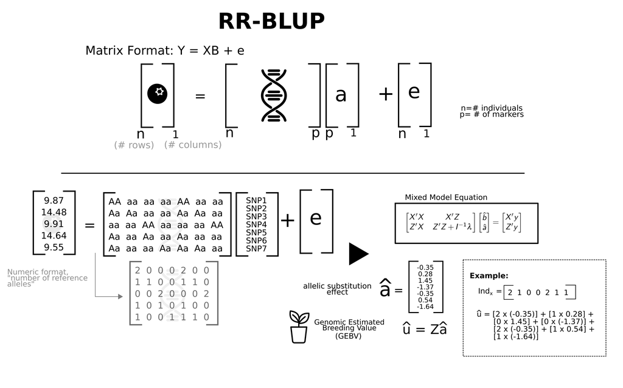

## 3.1 Hands on

```r
library(BGLR)
library(rrBLUP)

# Download the data
data(wheat)

# Dimensions
dim(wheat.X) # 599 ind 1279 markers
```

```
## [1]  599 1279
```

```r
dim(wheat.Y) # 599 ind 4 env
```

```
## [1] 599   4
```

```r
wheat.X[1:5,1:4]
```

```
##      wPt.0538 wPt.8463 wPt.6348 wPt.9992
## [1,]        0        1        1        1
## [2,]        1        1        1        1
## [3,]        1        1        1        1
## [4,]        0        1        1        1
## [5,]        0        1        1        1
```

```r
wheat.Y[1:5,1:4]
```

```
##               1           2          4          5
## 775   1.6716295 -1.72746986 -1.8902848  0.0509159
## 2166 -0.2527028  0.40952243  0.3093855 -1.7387588
## 2167  0.3418151 -0.64862633 -0.7995592 -1.0535691
## 2465  0.7854395  0.09394919  0.5704677  0.5517574
## 3881  0.9983176 -0.28248062  1.6186819 -0.1142848
```

- Estimate the marker effects
- Use the marker effects to predict the GEBV
- Correlate in TRN data set, GEBV with observed values

```r
# Fit RRBLUP for the environment 1
fit1 <- mixed.solve(y = wheat.Y[,1],
                    Z = wheat.X) # Estimating marker effects
str(fit1)
```

```
## List of 5
##  $ Vu  : num 0.00283
##  $ Ve  : num 0.541
##  $ beta: num [1(1d)] -1.25
##  $ u   : num [1:1279(1d)] -0.00213 0.03085 0.02107 0.01147 0.0068 ...
##   ..- attr(*, "dimnames")=List of 1
##   .. ..$ : chr [1:1279] "wPt.0538" "wPt.8463" "wPt.6348" "wPt.9992" ...
##  $ LL  : num -788
```

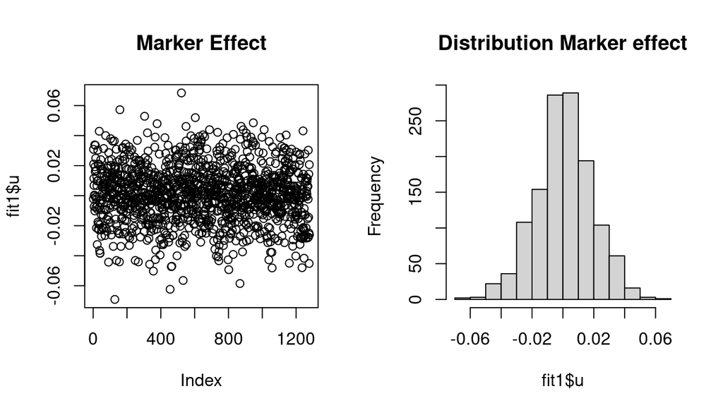

```r
# Ploting the marker effects
par(mfrow=c(1,2))
plot(fit1$u,main="Marker Effect")
hist(fit1$u, main = "Distribution Marker effect")
```

```r
# Lets check the effect of the first 10 SNPs
fit1$u[1:5]
```

```
##     wPt.0538     wPt.8463     wPt.6348     wPt.9992     wPt.2838
## -0.002132236  0.030845995  0.021065548  0.011471775  0.006798553
```

```r
# To compute the GEBV, I just need to multiple the SNP effect by the genotype
gebv = wheat.X %*% fit1$u # GEBV

# What is the correlation between predicted and real values?
cor(gebv,wheat.Y[,1]) # why correlation is so high?
```

```
##           [,1]
## [1,] 0.8144863
```

In the previus example we calibrated and fitted a genomic selection model in the same data set. During the class, we discussed about **overfitting** , that is an undesirable behavior that occurs when the model gives optimum accurate predictions for training data but not for new data. To avoid overfitting, we will use a cross-validation scheme using the following pipeline:

- Split our population into training and testing
- Estimate the marker effects in the training set
- Use the marker effects to predict the GEBV of the testing set
- Correlate in testing data set, GEBV with observed values

```r
# Test -- Selecting 100 ind to be test
y_tst = wheat.Y[1:100,1]
x_tst = wheat.X[1:100,]

# Train -- The rest will be part of the trait
y_trn = wheat.Y[-c(1:100),1]
x_trn = wheat.X[-c(1:100),]

# Fit the model in the TRN
fit4 <- mixed.solve(y = y_trn, Z = x_trn) # RR-BLUP

# Predict the TST
gebv_tst = x_tst %*% fit4$u ## GEBV

# Correlate the predicted and observed values in TST data set
cor(gebv_tst,y_tst)
```

```
##           [,1]
## [1,] 0.2505737
```

# 4 GBLUP

Genetic markers across the entire genome can be used to measure genetic similarities. Markers estimate proportion of chromosome segments shared by individuals including identification of genes identical by state (IBS). More details about the GBLUP is presented in this [link](https://htmlpreview.github.io/?https://github.com/lfelipe-ferrao/lfelipe-ferrao.github.io/blob/master/class/quantGenetic/week12.html).

Bellow the equation system that need to be solved to compute the GEBV:

$$\begin{bmatrix} {X'R^{-1}X} & {X'R^{-1}Z} \\ {Z'R^{-1}X}
& {Z'R^{-1}Z} + {G^{-1}\lambda} \end{bmatrix}
\begin{bmatrix} {\hat{b}}\\ {\hat{u}} \end{bmatrix}
=
\begin{bmatrix} {X'R^{-1}y} \\ {Z'R^{-1}y} \end{bmatrix}$$

$$\hat{b} =
(X'V^{-1}X)^{-1}XV^{-1}y$$

$$\hat{u} =
GZ'V^{-1}(y-X\hat{b})$$

Where the genomic relationship matrix can be computed using:

$$G= \dfrac{ZZ'}{2 \sum p_i (1-p_i)}
= \dfrac{(M-P)(M-P)'}{2 \sum^m_{j=1} p_j (1-p_j)}$$

Below we presented a simple representation of GBLUP method. When compared to the previus RR-BLUP representation,instead of treating marker as predictors, can predict additive values directly as multivariate normal effects. In this case, the markers are used to compute a covariance matrix that is proportional to genomic relationship matrix **G**.

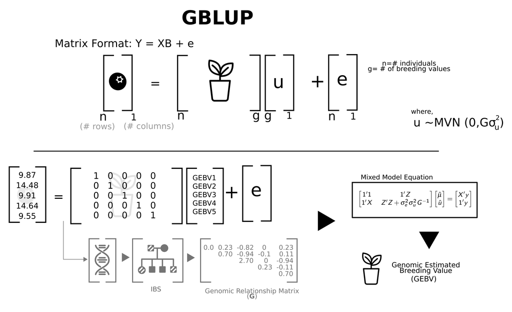

## 4.1 GBLUP and RR-BLUP are equivalent models

BLUP and RR-BLUP are equivalent models, as presented below:

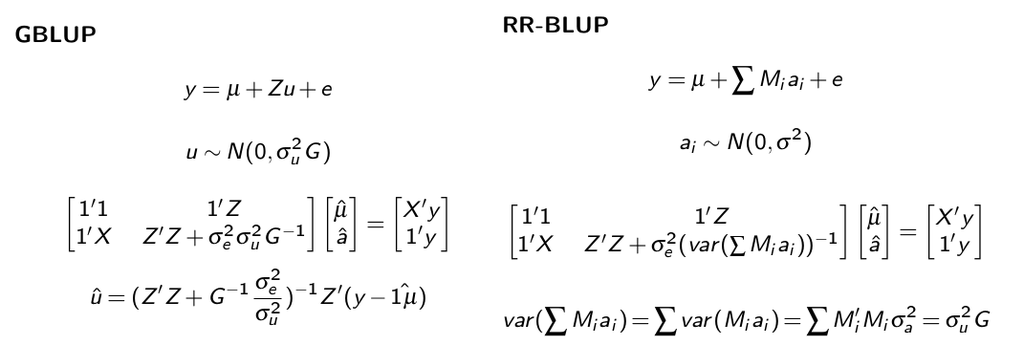

The use of GBLUP model has some important features that make it widely used in GS:

- GEBVs can be calculated in the same way as in pedigree-based BLUP, using software and concepts well known in breeding routines
- In contrast with the penalized regression (RR and LASSO), the dimensions of the genetic effects are reduced from p × p (where p is the number of markers) to n × n (where n is the number of individuals), which is more efficient for computing purposes.
- More complex models incorporating GxE interactions and multi-trait analysis can be easily included
- Pedigree and genomic data can be incorporated in the s0-called single step BLUPs

## 4.2 Hands on

In the sequence we will compare the results from RR-BLUP and GBLUP using the same data set and packages.

- Use the markers to compute the relationship matrix
- Compute the GEBV
- Predictive accuracy in the TRN data set
- Compare results from RR-BLUP and GBLUP

```r
# Fit GBLUP
G =A.mat(wheat.X) # Computing the G matrix
dim(G)
```

```
## [1] 599 599
```

```r
G[1:5,1:5]
```

```
##            [,1]       [,2]       [,3]      [,4]       [,5]
## [1,] 0.63639881 0.06326676 0.05945852 0.1711598 0.30006714
## [2,] 0.06326676 0.66683029 0.65786110 0.1038004 0.02110899
## [3,] 0.05945852 0.65786110 0.66953570 0.1025727 0.02504216
## [4,] 0.17115981 0.10380043 0.10257266 0.5265112 0.16512866
## [5,] 0.30006714 0.02110899 0.02504216 0.1651287 0.52369806
```

```r
fit2 <- mixed.solve(y = wheat.Y[,1], K = G) # Fit GBLUP
cor(fit2$u,wheat.Y[,1])
```

```
## [1] 0.8144891
```

```r
fit2$Vu/(fit2$Ve+fit2$Vu) # h2
```

```
## [1] 0.6695916
```

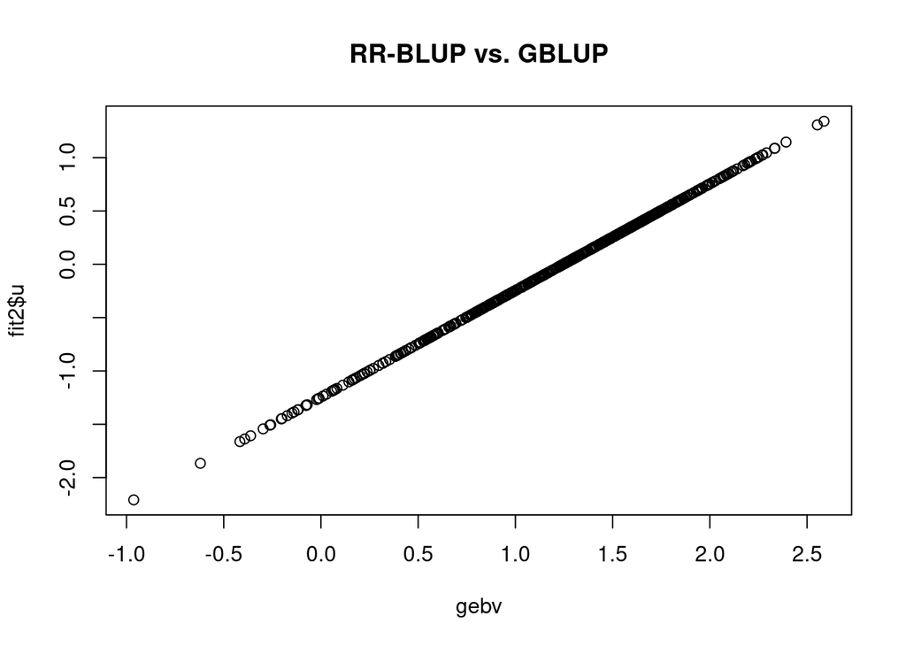

```r
plot(gebv, fit2$u, main = "RR-BLUP vs. GBLUP")
```

# 5 References

- Eldeman, 2011. Ridge Regression and Other Kernels for Genomic Selection with R Package rrBLUP. [Link for the paper](https://acsess.onlinelibrary.wiley.com/doi/10.3835/plantgenome2011.08.0024)
- Haines. On the equivalency between frequentist Ridge (and LASSO) regression and hierarchial Bayesian regression. [Website](http://haines-lab.com/post/on-the-equivalency-between-the-lasso-ridge-regression-and-specific-bayesian-priors/)
- Isik et al., 2017. Genetic Data Analysis for Plant and Animal Breeding. [Book link](https://www.springer.com/gp/book/9783319551753)
- Meuwissen et al., 2001. Prediction of total genetic value using genome-wide dense marker maps. [Link for the original paper](https://www.genetics.org/content/157/4/1819)
- Morota, 2017. ShinyGPAS: interactive genomic prediction accuracy simulator based on deterministic formulas. [Link paper](https://gsejournal.biomedcentral.com/articles/10.1186/s12711-017-0368-4)
- Mrode, 2014. Linear Models for the Prediction of Animal Breeding Values. [Book link](https://www.amazon.com/Linear-Models-Prediction-Animal-Breeding/dp/1845939816)
- Pérez, P., & de los Campos, G. (2014). BGLR: a statistical package for whole genome regression and prediction. Genetics, 198(2), 483-495. [Link paper](http://genomics.cimmyt.org/BGLR-extdoc.pdf)
- Van Raden, 2008. Efficient Methods to Compute Genomic Predictions [Link for the paper](https://www.sciencedirect.com/science/article/pii/S0022030208709901)

[figure not shown]